# 01_Introduction

Tobias Gerstenberg

1/7/2019

## Student feedback

> I really liked the setup of going through the markdown file and doing examples together. It made very easy to jump ahead when we finish early and made it feel like a very efficient use of time

> I liked being able to work through the exercises. I wished we had more clear “learning goals” laid out at the start of the class.

> I think it may be more useful to have us to the practice exercises at home/outside of class and use class time to go over ideas/concepts etc…

> Writing all the packages we need to install in the Rmd file somewhere so we can just copy and paste into console, instead of installing along the way. I did appreciate it being in the email, but it’s easier to have it in Rmd so that I don’t have to have another window open

> Maybe telling everyone which line we are at now would help. Sometimes I lost track of where we were in the .Rmd file

|  | response |
| --- | --- |
| 1 | I really liked the setup of going through the markdown file and doing examples together. It made very easy to jump ahead when we finish early and made it feel like a very efficient use of time |
| 2 | are students without programming experience able to keep up? I have experience but I felt I had to draw on it a lot in order to complete what was going on |
| 3 | The pace is a bit slower, but it is expected for a beginner course. In general, the class is great |
| 4 | It was great. I just had to figure out some things when installing packages (my version wouldn't allow me to install without specifying dependencies=TRUE, repos='http://cran.rstudio.com/' so I had to … |
| 5 | I like that we get hands-on practice in lecture. |
| 6 | Maybe telling everyone which line we are at now would help. Sometimes I lost track of where we were in the .Rmd file |
| 7 | If the goal is to follow along with you, we need slightly more explicit indication of where you are in your code (e.g. line number) and what concept you are demonstrating at that time. |
| 8 | The Rmd files for the lecture are great -- really comprehensive and will be helpful resources moving forward. It's tough with technical issues that the TAs need to help students with while we need to … |
| 9 | The walkthrough of ggplot made things much clearer! I'm hoping to learn how to apply these skills with actual psych data that's a little less straightforward (like how to plot the output of a regressi… |
| 10 | I like doing in-class exercises but towards the end I was out of sync: was still working on the previous example so I couldn't focus on your introduction of the new topic. |

[output cut: 30 more lines]

### PollEverywhere results

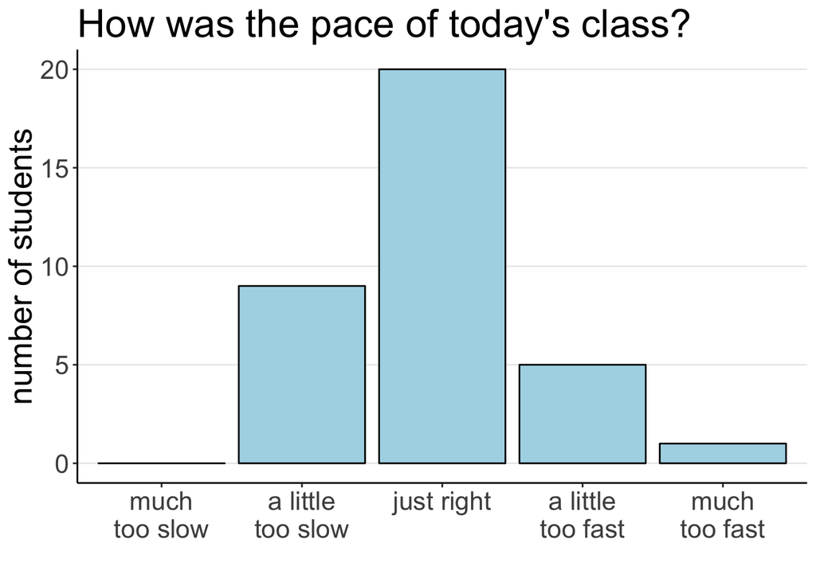

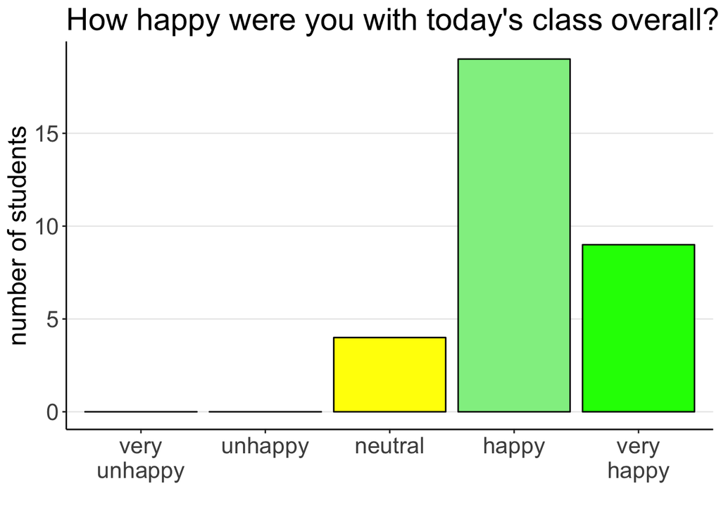

## What to do next time

- stress test materials
  - the figures were missing and it took students a while to download the new materials
- make sure that my .Rmd file doesn’t already have the plots pre-loaded
- we only managed to get until section “Adding error bars” (incl. practice 2)